# RSA

AC, SB, CPH

2026-03-05

# Memory Performance

## Specific source memory increased for high reward memoranda after 24 hrs across all ages

0. Linear age model is best-fitting
1. Main effects of reward level (p < 0.001) and retrieval condition (p < 0.001)

```
## Data: assochitd2.long
## Models:
## assocmemmodelagelin: mem ~ RewardType * RetCond * ageScaled + HighRewardStim + (1 | subid)
## assocmemmodelagesq: mem ~ RewardType * RetCond * ageScaled + RewardType * RetCond * ageScaledsq + HighRewardStim + (1 | subid)
##                     npar     AIC     BIC logLik -2*log(L)  Chisq Df Pr(>Chisq)
## assocmemmodelagelin   11 -570.13 -527.51 296.07   -592.13
## assocmemmodelagesq    15 -564.11 -505.99 297.06   -594.11 1.9795  4     0.7395
```

```
## Analysis of Deviance Table (Type III Wald chisquare tests)
##
## Response: mem
##                                 Chisq Df Pr(>Chisq)
## (Intercept)                  825.5357  1  < 2.2e-16 ***
## RewardType                    17.8924  1  2.338e-05 ***
## RetCond                       49.5615  1  1.922e-12 ***
## ageScaled                      1.9936  1     0.1580
## HighRewardStim                 0.6316  1     0.4268
## RewardType:RetCond             1.8486  1     0.1739
## RewardType:ageScaled           0.0000  1     0.9995
## RetCond:ageScaled              0.1990  1     0.6555
## RewardType:RetCond:ageScaled   0.7667  1     0.3812
## ---
## Signif. codes:  0 '***' 0.001 '**' 0.01 '*' 0.05 '.' 0.1 ' ' 1
```

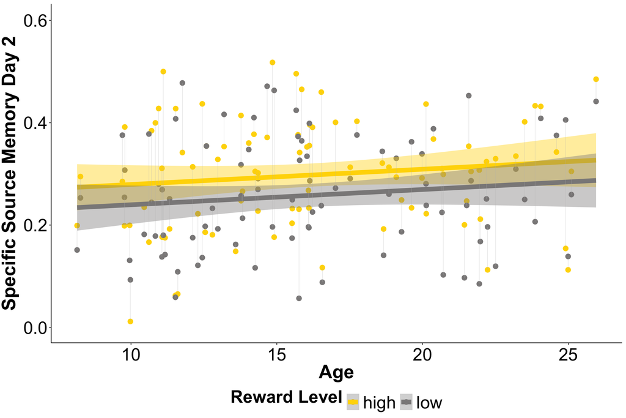

2. Similar pattern of results when including only items that were retrieved on Day 1; significant effect of reward type (p = .011), marginal effect of age (p = .087)

```
## Analysis of Deviance Table (Type III Wald chisquare tests)
##
## Response: mem
##                          Chisq Df Pr(>Chisq)
## (Intercept)          1132.2078  1    < 2e-16 ***
## RewardType              6.5022  1    0.01077 *
## ageScaled               2.9200  1    0.08749 .
## HighRewardStim          0.4318  1    0.51108
## RewardType:ageScaled    0.6043  1    0.43694
## ---
## Signif. codes:  0 '***' 0.001 '**' 0.01 '*' 0.05 '.' 0.1 ' ' 1
```

# VTC Pattern Similarity

## ERS

```
## Data: VTCers.long
## Models:
## VTCersd1modelagelin: similarity ~ RewardType * ageScaled + HighRewardStim + (1 | subid)
## VTCersd1modelagesq: similarity ~ RewardType * ageScaled + RewardType * ageScaledsq + HighRewardStim + (1 | subid)
##                     npar     AIC     BIC logLik -2*log(L)  Chisq Df Pr(>Chisq)
## VTCersd1modelagelin    7 -635.77 -613.50 324.88   -649.77
## VTCersd1modelagesq     9 -639.19 -610.56 328.60   -657.19 7.4258  2    0.02441
##
## VTCersd1modelagelin
## VTCersd1modelagesq  *
## ---
## Signif. codes:  0 '***' 0.001 '**' 0.01 '*' 0.05 '.' 0.1 ' ' 1
```

```
## Analysis of Deviance Table (Type III Wald chisquare tests)
##
## Response: similarity
##                           Chisq Df Pr(>Chisq)
## (Intercept)            160.5749  1  < 2.2e-16 ***
## RewardType               1.5529  1   0.212712
## ageScaled                0.9232  1   0.336647
## ageScaledsq              7.0190  1   0.008065 **
## HighRewardStim           0.3076  1   0.579187
## RewardType:ageScaled     0.0256  1   0.872976
## RewardType:ageScaledsq   0.3526  1   0.552618
## ---
## Signif. codes:  0 '***' 0.001 '**' 0.01 '*' 0.05 '.' 0.1 ' ' 1
```

```
## [1] Sensitivity analysis controlling for voxel number
```

```
## Analysis of Deviance Table (Type III Wald chisquare tests)
##
## Response: similarity
##                           Chisq Df Pr(>Chisq)
## (Intercept)            160.1296  1  < 2.2e-16 ***
## RewardType               1.5529  1   0.212712
## ageScaled                0.8688  1   0.351278
## ageScaledsq              6.9375  1   0.008441 **
## HighRewardStim           0.3129  1   0.575930
## goldencvoxnumScaled      0.6727  1   0.412125
## RewardType:ageScaled     0.0256  1   0.872976
## RewardType:ageScaledsq   0.3526  1   0.552618
## ---
## Signif. codes:  0 '***' 0.001 '**' 0.01 '*' 0.05 '.' 0.1 ' ' 1
```

```
## [1] Sensitivity analysis removing 1 run subs
```

```
## Analysis of Deviance Table (Type III Wald chisquare tests)
##
## Response: similarity
##                           Chisq Df Pr(>Chisq)
## (Intercept)            134.2317  1    < 2e-16 ***
## RewardType               0.8491  1    0.35679
## ageScaled                0.4723  1    0.49193
## ageScaledsq              3.9887  1    0.04581 *
## HighRewardStim           1.0225  1    0.31192
## RewardType:ageScaled     0.1597  1    0.68940
## RewardType:ageScaledsq   0.4044  1    0.52482
## ---
## Signif. codes:  0 '***' 0.001 '**' 0.01 '*' 0.05 '.' 0.1 ' ' 1
```

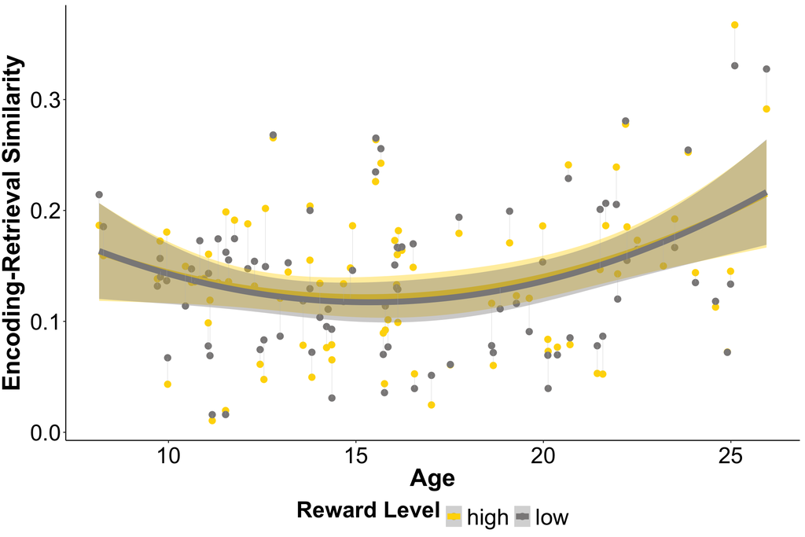

## Encoding Similarity

0. Linear age model is best-fitting
1. Main effects of reward level (p < 0.001) and age (p < 0.05), regardless of controlling for voxel number or removing 1 run subs

```
## Data: VTCencsim.long
## Models:
## VTCencsimd1modelagelin: similarity ~ RewardType * ageScaled + HighRewardStim + (1 | subid)
## VTCencsimd1modelagesq: similarity ~ RewardType * ageScaled + RewardType * ageScaledsq + HighRewardStim + (1 | subid)
##                        npar     AIC     BIC logLik -2*log(L)  Chisq Df
## VTCencsimd1modelagelin    7 -434.15 -413.27 224.08   -448.15
## VTCencsimd1modelagesq     9 -431.66 -404.81 224.83   -449.66 1.5103  2
##                        Pr(>Chisq)
## VTCencsimd1modelagelin
## VTCencsimd1modelagesq      0.4699
```

```
## Analysis of Deviance Table (Type III Wald chisquare tests)
##
## Response: similarity
##                         Chisq Df Pr(>Chisq)
## (Intercept)          257.9367  1  < 2.2e-16 ***
## RewardType            13.8480  1  0.0001982 ***
## ageScaled              4.3820  1  0.0363212 *
## HighRewardStim         1.3402  1  0.2469974
## RewardType:ageScaled   0.1209  1  0.7280601
## ---
## Signif. codes:  0 '***' 0.001 '**' 0.01 '*' 0.05 '.' 0.1 ' ' 1
```

```
## [1] Sensitivity analysis controlling for voxel number
```

```
## Analysis of Deviance Table (Type III Wald chisquare tests)
##
## Response: similarity
##                         Chisq Df Pr(>Chisq)
## (Intercept)          257.4219  1  < 2.2e-16 ***
## RewardType            13.8480  1  0.0001982 ***
## ageScaled              3.8598  1  0.0494559 *
## HighRewardStim         1.3290  1  0.2489831
## goldencvoxnumScaled    0.7466  1  0.3875695
## RewardType:ageScaled   0.1209  1  0.7280601
## ---
## Signif. codes:  0 '***' 0.001 '**' 0.01 '*' 0.05 '.' 0.1 ' ' 1
```

```
## [1] Sensitivity analysis removing 1 run subs
```

```
## Analysis of Deviance Table (Type III Wald chisquare tests)
##
## Response: similarity
##                         Chisq Df Pr(>Chisq)
## (Intercept)          257.9367  1  < 2.2e-16 ***
## RewardType            13.8480  1  0.0001982 ***
## ageScaled              4.3820  1  0.0363212 *
## HighRewardStim         1.3402  1  0.2469974
## RewardType:ageScaled   0.1209  1  0.7280601
## ---
## Signif. codes:  0 '***' 0.001 '**' 0.01 '*' 0.05 '.' 0.1 ' ' 1
```

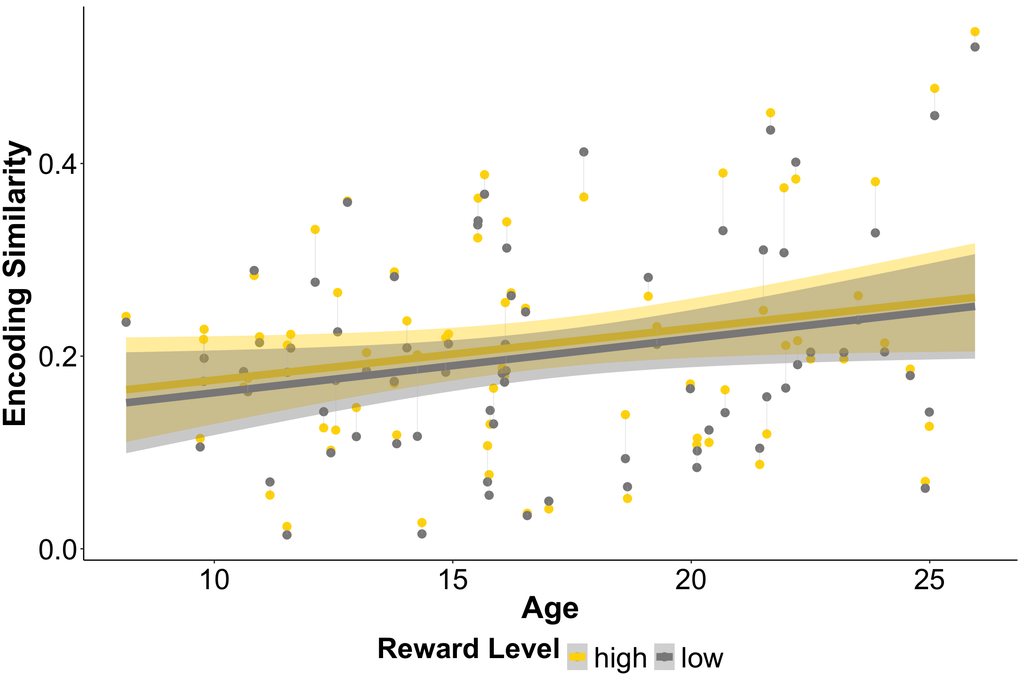

## Retrieval Similarity

0. Linear age model is best-fitting
1. No effects

```
## Data: VTCretsim.long
## Models:
## VTCretsimd1modelagelin: similarity ~ RewardType * ageScaled + HighRewardStim + (1 | subid)
## VTCretsimd1modelagesq: similarity ~ RewardType * ageScaled + RewardType * ageScaledsq + HighRewardStim + (1 | subid)
##                        npar     AIC     BIC logLik -2*log(L)  Chisq Df
## VTCretsimd1modelagelin    7 -530.23 -509.34 272.11   -544.23
## VTCretsimd1modelagesq     9 -530.35 -503.50 274.17   -548.35 4.1215  2
##                        Pr(>Chisq)
## VTCretsimd1modelagelin
## VTCretsimd1modelagesq      0.1274
```

```
## Analysis of Deviance Table (Type III Wald chisquare tests)
##
## Response: similarity
##                         Chisq Df Pr(>Chisq)
## (Intercept)          378.3351  1     <2e-16 ***
## RewardType             0.9268  1     0.3357
## ageScaled              1.4320  1     0.2314
## HighRewardStim         1.4449  1     0.2293
## RewardType:ageScaled   0.0286  1     0.8656
## ---
## Signif. codes:  0 '***' 0.001 '**' 0.01 '*' 0.05 '.' 0.1 ' ' 1
```

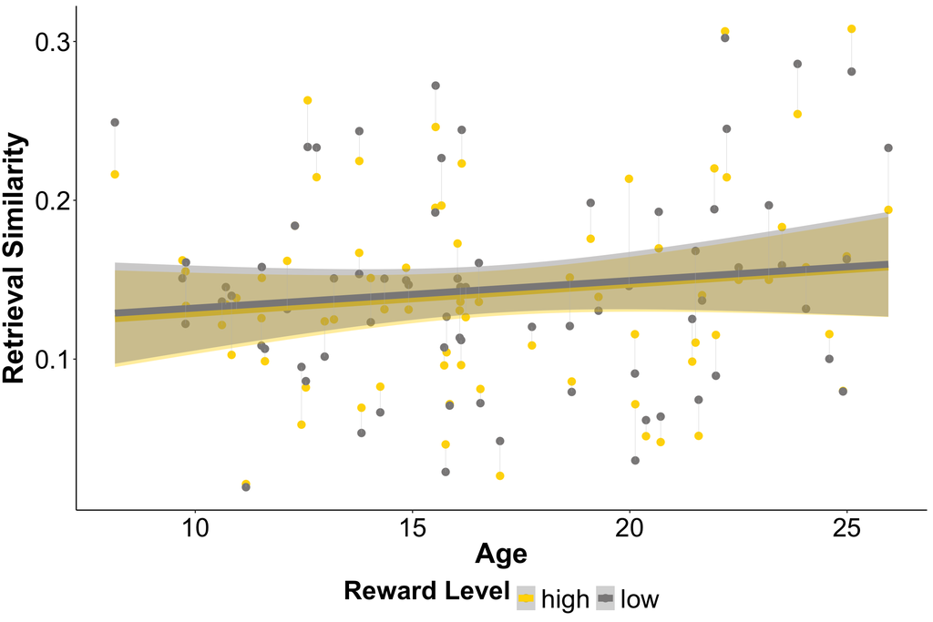

# Anterior Hippocampus Pattern Similarity

## ERS

```
## Data: anthippers.long
## Models:
## anthippersd1modelagelin: similarity ~ RewardType * ageScaled + HighRewardStim + (1 | subid)
## anthippersd1modelagesq: similarity ~ RewardType * ageScaled + RewardType * ageScaledsq + HighRewardStim + (1 | subid)
##                         npar     AIC     BIC logLik -2*log(L)  Chisq Df
## anthippersd1modelagelin    7 -764.18 -741.91 389.09   -778.18
## anthippersd1modelagesq     9 -763.92 -735.28 390.96   -781.92 3.7401  2
##                         Pr(>Chisq)
## anthippersd1modelagelin
## anthippersd1modelagesq      0.1541
```

```
## Analysis of Deviance Table (Type III Wald chisquare tests)
##
## Response: similarity
##                       Chisq Df Pr(>Chisq)
## (Intercept)          2.4476  1   0.117707
## RewardType           1.5299  1   0.216122
## ageScaled            1.5259  1   0.216727
## HighRewardStim       0.0029  1   0.956885
## RewardType:ageScaled 9.4089  1   0.002159 **
## ---
## Signif. codes:  0 '***' 0.001 '**' 0.01 '*' 0.05 '.' 0.1 ' ' 1
```

```
## [1] Sensitivity analysis controlling for voxel number
```

```
## Analysis of Deviance Table (Type III Wald chisquare tests)
##
## Response: similarity
##                       Chisq Df Pr(>Chisq)
## (Intercept)          2.4261  1   0.119327
## RewardType           1.5299  1   0.216122
## ageScaled            1.5405  1   0.214549
## HighRewardStim       0.0033  1   0.954171
## goldencvoxnumScaled  0.2511  1   0.616322
## RewardType:ageScaled 9.4089  1   0.002159 **
## ---
## Signif. codes:  0 '***' 0.001 '**' 0.01 '*' 0.05 '.' 0.1 ' ' 1
```

```
## [1] Sensitivity analysis removing 1 run subs
```

```
## Analysis of Deviance Table (Type III Wald chisquare tests)
##
## Response: similarity
##                       Chisq Df Pr(>Chisq)
## (Intercept)          1.0369  1     0.3086
## RewardType           1.1451  1     0.2846
## ageScaled            0.1238  1     0.7250
## HighRewardStim       0.0297  1     0.8632
## RewardType:ageScaled 4.9365  1     0.0263 *
## ---
## Signif. codes:  0 '***' 0.001 '**' 0.01 '*' 0.05 '.' 0.1 ' ' 1
```

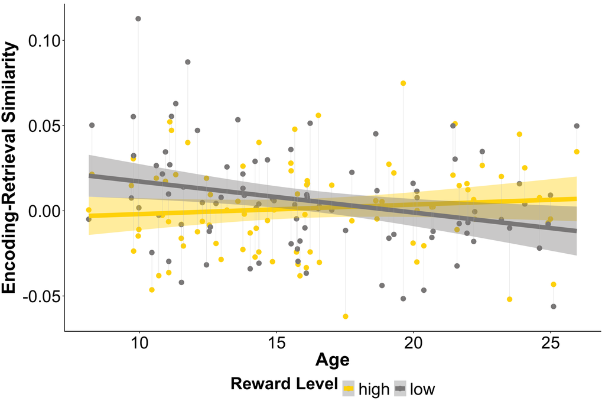

## Encoding Similarity

0. Linear age model is best-fitting
1. No effects, regardless of controlling for voxel number

```
## Data: anthippencsim.long
## Models:
## anthippencsimd1modelagelin: similarity ~ RewardType * ageScaled + HighRewardStim + (1 | subid)
## anthippencsimd1modelagesq: similarity ~ RewardType * ageScaled + RewardType * ageScaledsq + HighRewardStim + (1 | subid)
##                            npar     AIC     BIC logLik -2*log(L)  Chisq Df
## anthippencsimd1modelagelin    7 -731.95 -711.07 372.98   -745.95
## anthippencsimd1modelagesq     9 -729.11 -702.26 373.55   -747.11 1.1562  2
##                            Pr(>Chisq)
## anthippencsimd1modelagelin
## anthippencsimd1modelagesq       0.561
```

```
## Analysis of Deviance Table (Type III Wald chisquare tests)
##
## Response: similarity
##                        Chisq Df Pr(>Chisq)
## (Intercept)          26.1044  1  3.234e-07 ***
## RewardType            0.3252  1     0.5685
## ageScaled             0.2013  1     0.6537
## HighRewardStim        0.9699  1     0.3247
## RewardType:ageScaled  1.0964  1     0.2951
## ---
## Signif. codes:  0 '***' 0.001 '**' 0.01 '*' 0.05 '.' 0.1 ' ' 1
```

```
## [1] Sensitivity analysis controlling for voxel number
```

```
## Analysis of Deviance Table (Type III Wald chisquare tests)
##
## Response: similarity
##                        Chisq Df Pr(>Chisq)
## (Intercept)          27.5386  1   1.54e-07 ***
## RewardType            0.3252  1     0.5685
## ageScaled             0.4009  1     0.5266
## HighRewardStim        0.9004  1     0.3427
## goldencvoxnumScaled   1.6902  1     0.1936
## RewardType:ageScaled  1.0964  1     0.2951
## ---
## Signif. codes:  0 '***' 0.001 '**' 0.01 '*' 0.05 '.' 0.1 ' ' 1
```

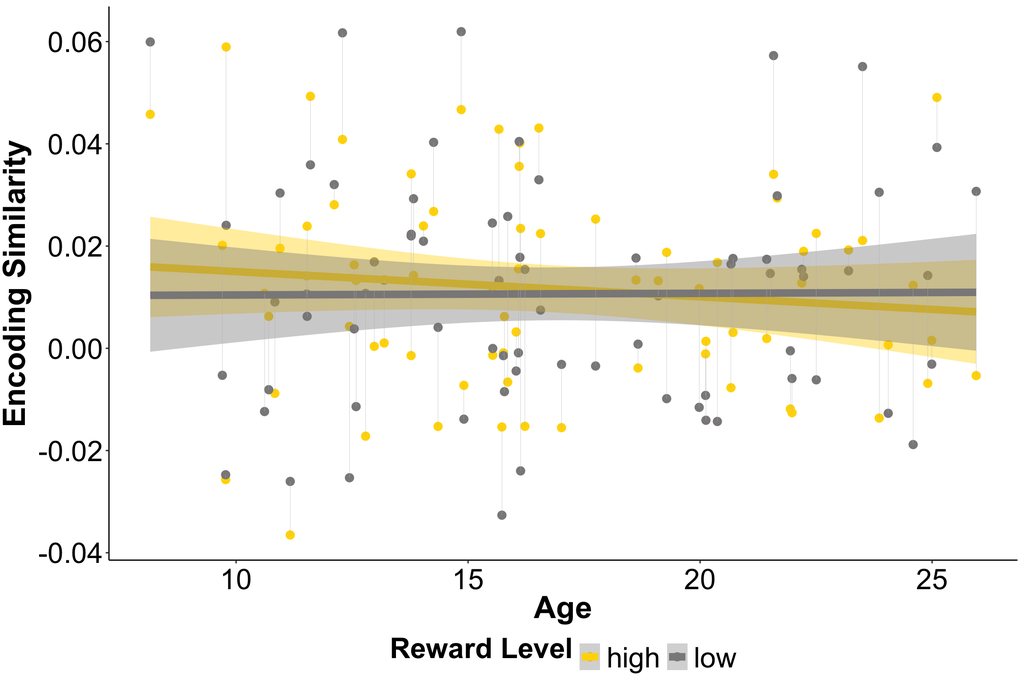

## Retrieval Similarity

0. Linear age model is best-fitting
1. No effects, regardless of controlling for voxel number

```
## Data: anthippretsim.long
## Models:
## anthippretsimd1modelagelin: similarity ~ RewardType * ageScaled + HighRewardStim + (1 | subid)
## anthippretsimd1modelagesq: similarity ~ RewardType * ageScaled + RewardType * ageScaledsq + HighRewardStim + (1 | subid)
##                            npar     AIC     BIC logLik -2*log(L)  Chisq Df
## anthippretsimd1modelagelin    7 -690.46 -669.57 352.23   -704.46
## anthippretsimd1modelagesq     9 -689.77 -662.92 353.89   -707.77 3.3117  2
##                            Pr(>Chisq)
## anthippretsimd1modelagelin
## anthippretsimd1modelagesq      0.1909
```

```
## Analysis of Deviance Table (Type III Wald chisquare tests)
##
## Response: similarity
##                        Chisq Df Pr(>Chisq)
## (Intercept)          28.2522  1  1.065e-07 ***
## RewardType            0.8867  1     0.3464
## ageScaled             0.1883  1     0.6643
## HighRewardStim        0.0311  1     0.8600
## RewardType:ageScaled  0.5084  1     0.4758
## ---
## Signif. codes:  0 '***' 0.001 '**' 0.01 '*' 0.05 '.' 0.1 ' ' 1
```

```
## [1] Sensitivity analysis controlling for voxel number
```

```
## Analysis of Deviance Table (Type III Wald chisquare tests)
##
## Response: similarity
##                        Chisq Df Pr(>Chisq)
## (Intercept)          28.9388  1   7.47e-08 ***
## RewardType            0.8867  1     0.3464
## ageScaled             0.0878  1     0.7669
## HighRewardStim        0.0217  1     0.8828
## goldretvoxnumScaled   0.8502  1     0.3565
## RewardType:ageScaled  0.5084  1     0.4758
## ---
## Signif. codes:  0 '***' 0.001 '**' 0.01 '*' 0.05 '.' 0.1 ' ' 1
```

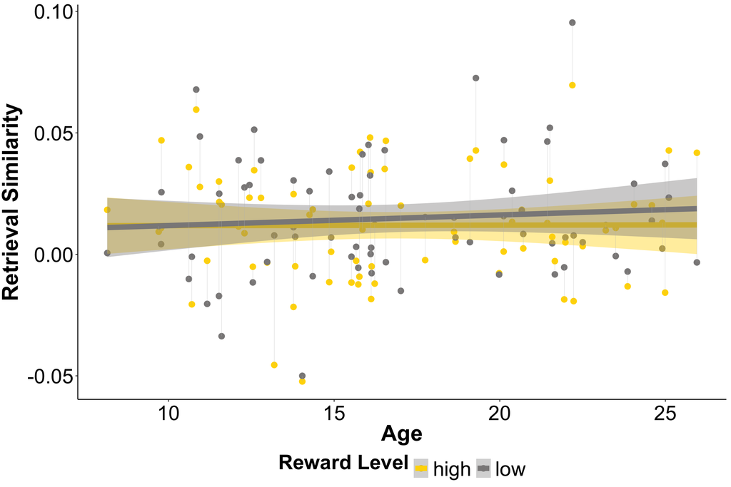

# Brain-Behavior & Brain-Brain Relations

## Trialwise VTC ERS

- Greater VTC ERS is associated with better specific source memory on day 2

```
## [1] Stats model
```

```
## Analysis of Deviance Table (Type III Wald chisquare tests)
##
## Response: memory
##                  Chisq Df Pr(>Chisq)
## (Intercept)     0.2344  1   0.628262
## ERSZ           17.0403  1  3.659e-05 ***
## RewardType      7.2571  1   0.007062 **
## ageScaled       4.2181  1   0.039995 *
## HighRewardStim  0.0072  1   0.932515
## ---
## Signif. codes:  0 '***' 0.001 '**' 0.01 '*' 0.05 '.' 0.1 ' ' 1
```

```
## [1] Plotting model
```

```
## Analysis of Deviance Table (Type III Wald chisquare tests)
##
## Response: memory
##                  Chisq Df Pr(>Chisq)
## (Intercept)     3.0671  1   0.079893 .
## ERS            17.0459  1  3.649e-05 ***
## RewardType      7.2570  1   0.007062 **
## ageScaled       4.2181  1   0.039995 *
## HighRewardStim  0.0072  1   0.932514
## ---
## Signif. codes:  0 '***' 0.001 '**' 0.01 '*' 0.05 '.' 0.1 ' ' 1
```

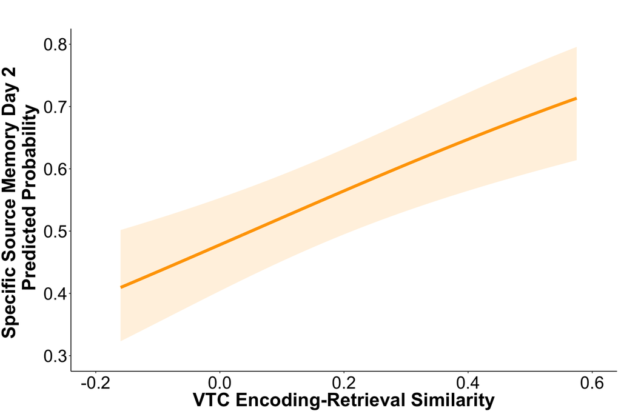

## Memory vs. Hippocampal ERS, VTC Encoding Similarity

- AntHipp ERS absolute value = significant
- VTC encoding similarity = marginal

```
##
## Call:
## lm(formula = highvlowspecificmemd2 ~ highvlowERSabs + VTC.highvlowencsim +
##     ageScaled + HighRewardStim, data = anthippRSAdatawbehavfullruns)
##
## Residuals:
##       Min        1Q    Median        3Q       Max
## -0.284679 -0.062186  0.004287  0.051144  0.217183
##
## Coefficients:
##                                        Estimate Std. Error t value Pr(>|t|)
## (Intercept)                           -0.024624   0.024368  -1.010  0.31585
## highvlowERSabs                         2.698326   0.788071   3.424  0.00105 **
## VTC.highvlowencsim                     0.841374   0.463675   1.815  0.07400 .
## ageScaled                              0.001505   0.012110   0.124  0.90144
## HighRewardStimHigh Reward Cat - Place -0.003522   0.024083  -0.146  0.88415
## ---
## Signif. codes:  0 '***' 0.001 '**' 0.01 '*' 0.05 '.' 0.1 ' ' 1
##
## Residual standard error: 0.1024 on 68 degrees of freedom
## Multiple R-squared:  0.2029, Adjusted R-squared:  0.156
## F-statistic: 4.328 on 4 and 68 DF,  p-value: 0.003536
```

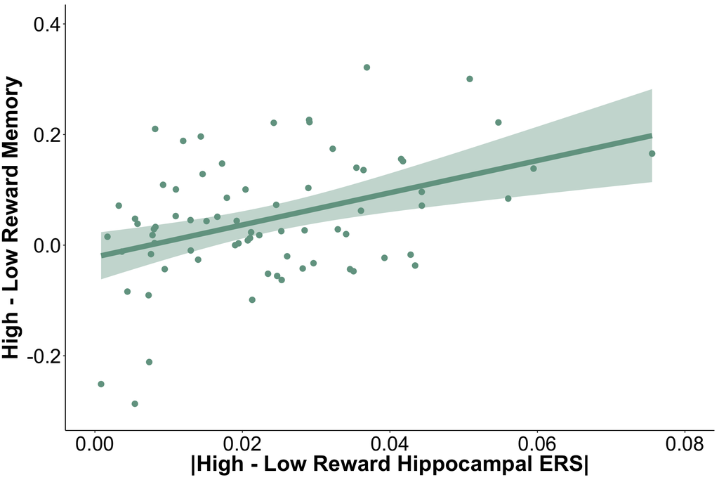

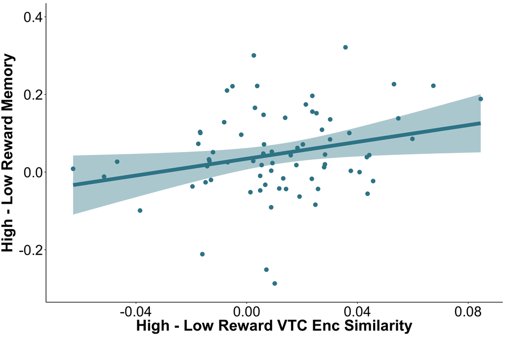

## Hippocampal ERS vs. VTA Encoding Activation

- VTA encoding activation = significant
- age = marginal

```
##
## Call:
## lm(formula = highvlowERS ~ VTA * ageScaled + HighRewardStim,
##     data = anthippRSAdatawbehavfullruns)
##
## Residuals:
##       Min        1Q    Median        3Q       Max
## -0.072556 -0.017396 -0.000258  0.019100  0.058890
##
## Coefficients:
##                                         Estimate Std. Error t value Pr(>|t|)
## (Intercept)                           -0.0007279  0.0049501  -0.147   0.8835
## VTA                                   -0.0216526  0.0095308  -2.272   0.0263 *
## ageScaled                              0.0073882  0.0040890   1.807   0.0752 .
## HighRewardStimHigh Reward Cat - Place  0.0021026  0.0066552   0.316   0.7530
## VTA:ageScaled                          0.0068634  0.0112692   0.609   0.5445
## ---
## Signif. codes:  0 '***' 0.001 '**' 0.01 '*' 0.05 '.' 0.1 ' ' 1
##
## Residual standard error: 0.02708 on 68 degrees of freedom
## Multiple R-squared:  0.1335, Adjusted R-squared:  0.08252
## F-statistic: 2.619 on 4 and 68 DF,  p-value: 0.04243
```

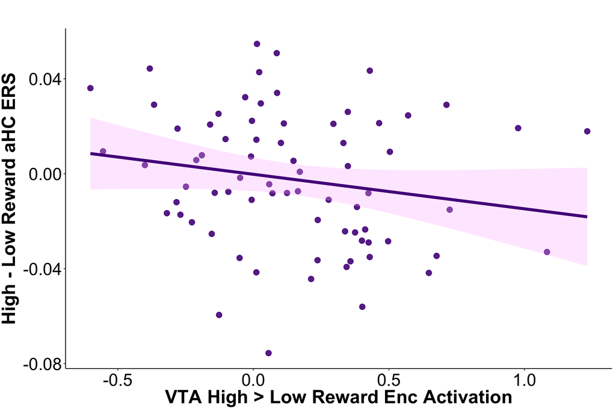

# Follow-Up and Supplemental Analyses

## ERS by non-linear age

Two-lines test

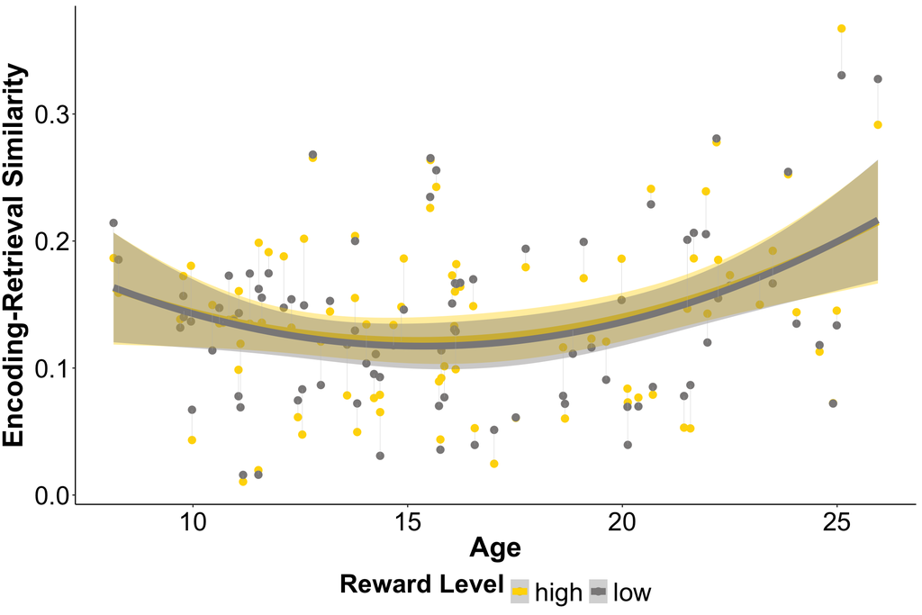

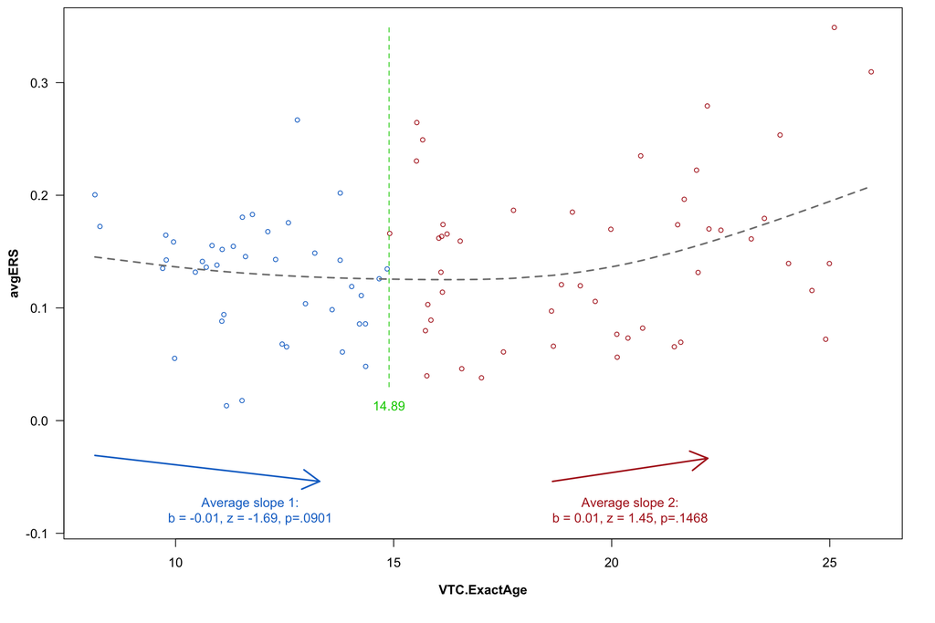

## AntHipp ERS by age group instead of continuous age

Age group model

```
## Linear mixed model fit by maximum likelihood . t-tests use Satterthwaite's
##   method [lmerModLmerTest]
## Formula: similarity ~ RewardType * AgeGroup + HighRewardStim + (1 | subid)
##    Data: anthippers.long
## Control: lmerControl(optimizer = "bobyqa", optCtrl = list(maxfun = 1e+06))
##
##       AIC       BIC    logLik -2*log(L)  df.resid
##    -761.9    -733.2     389.9    -779.9       169
##
## Scaled residuals:
##     Min      1Q  Median      3Q     Max
## -2.2187 -0.5948 -0.0380  0.5835  3.3050
##
## Random effects:
##  Groups   Name        Variance  Std.Dev.
##  subid    (Intercept) 0.0002006 0.01416
##  Residual             0.0005587 0.02364
## Number of obs: 178, groups:  subid, 89
##
## Fixed effects:
##                                         Estimate Std. Error         df t value
## (Intercept)                            7.402e-03  5.542e-03  1.541e+02   1.336
## RewardTypelow                         -1.057e-02  6.103e-03  8.900e+01  -1.732
## AgeGroup2                             -1.019e-02  7.058e-03  1.664e+02  -1.444
## AgeGroup3                             -7.671e-03  7.243e-03  1.664e+02  -1.059
## HighRewardStimHigh Reward Cat - Place  8.537e-05  4.649e-03  8.900e+01   0.018
## RewardTypelow:AgeGroup2                1.736e-02  8.561e-03  8.900e+01   2.028
## RewardTypelow:AgeGroup3                2.856e-02  8.784e-03  8.900e+01   3.251
##                                       Pr(>|t|)
## (Intercept)                            0.18363
## RewardTypelow                          0.08668 .
## AgeGroup2                              0.15054
## AgeGroup3                              0.29106
## HighRewardStimHigh Reward Cat - Place  0.98539
## RewardTypelow:AgeGroup2                0.04555 *
## RewardTypelow:AgeGroup3                0.00162 **
## ---
## Signif. codes:  0 '***' 0.001 '**' 0.01 '*' 0.05 '.' 0.1 ' ' 1
##
## Correlation of Fixed Effects:
##             (Intr) RwrdTy AgGrp2 AgGrp3 HRRC-P RT:AG2
## RewardTyplw -0.551
## AgeGroup2   -0.652  0.432
## AgeGroup3   -0.621  0.421  0.495
## HghRwSHRC-P -0.419  0.000  0.011 -0.023
## RwrdTyp:AG2  0.393 -0.713 -0.607 -0.300  0.000
## RwrdTyp:AG3  0.383 -0.695 -0.300 -0.606  0.000  0.495
```

Examine marginal means from reward x age group interaction

```
## AgeGroup = 1:
##  contrast   estimate      SE   df t.ratio p.value
##  high - low  0.01057 0.00621 92.1   1.703  0.0920
##
## AgeGroup = 2:
##  contrast   estimate      SE   df t.ratio p.value
##  high - low -0.00679 0.00611 92.1  -1.112  0.2692
##
## AgeGroup = 3:
##  contrast   estimate      SE   df t.ratio p.value
##  high - low -0.01798 0.00643 92.1  -2.798  0.0063
##
## Results are averaged over the levels of: HighRewardStim
## Degrees-of-freedom method: kenward-roger
```

Plot ERS by age group

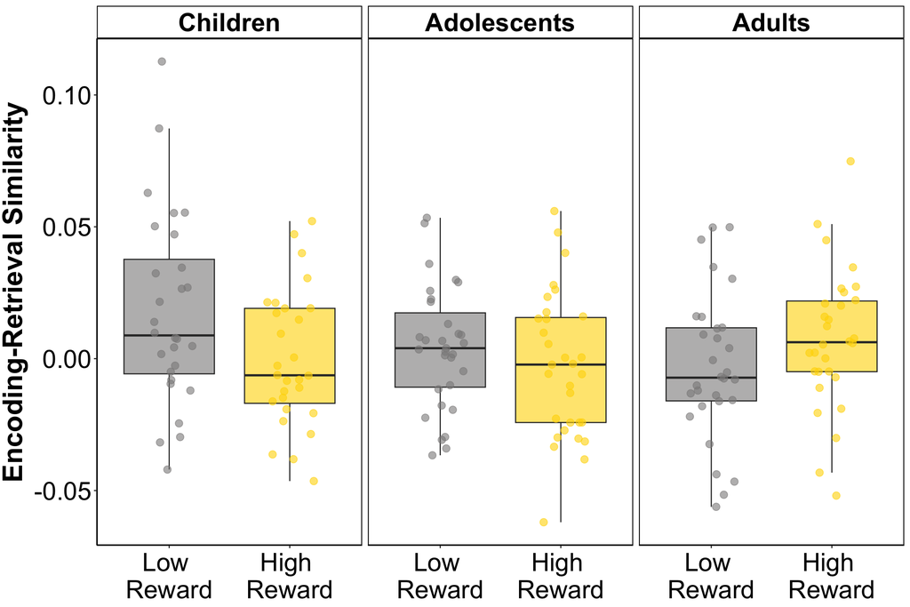

## AntHipp ERS by correct/incorrect, separately for adults and children

```
## Linear mixed model fit by REML. t-tests use Satterthwaite's method [
## lmerModLmerTest]
## Formula: ERSZ ~ ageScaled * memory * RewardType + HighRewardStim + (1 |
##     subid)
##    Data: trialwiseaHCERSwdemog
##
## REML criterion at convergence: 14724.1
##
## Scaled residuals:
##     Min      1Q  Median      3Q     Max
## -3.5847 -0.6672 -0.0071  0.6455  4.3866
##
## Random effects:
##  Groups   Name        Variance Std.Dev.
##  subid    (Intercept) 0.01625  0.1275
##  Residual             0.98399  0.9920
## Number of obs: 5184, groups:  subid, 89
##
## Fixed effects:
##                                         Estimate Std. Error         df t value
## (Intercept)                           -1.560e-02  3.752e-02  2.599e+02  -0.416
## ageScaled                              1.952e-02  3.176e-02  4.909e+02   0.615
## memory                                 3.677e-03  4.015e-02  4.832e+03   0.092
## RewardTypeLow                          2.929e-02  3.970e-02  5.142e+03   0.738
## HighRewardStimHigh Reward Cat - Place  9.879e-05  3.888e-02  8.095e+01   0.003
## ageScaled:memory                      -1.270e-04  4.034e-02  4.539e+03  -0.003
## ageScaled:RewardTypeLow               -7.434e-02  3.919e-02  5.150e+03  -1.897
## memory:RewardTypeLow                   3.019e-03  5.570e-02  5.168e+03   0.054
## ageScaled:memory:RewardTypeLow        -1.166e-02  5.575e-02  5.174e+03  -0.209
##                                       Pr(>|t|)
## (Intercept)                             0.6779
## ageScaled                               0.5391
## memory                                  0.9270
## RewardTypeLow                           0.4607
## HighRewardStimHigh Reward Cat - Place   0.9980
## ageScaled:memory                        0.9975
## ageScaled:RewardTypeLow                 0.0579 .
## memory:RewardTypeLow                    0.9568
## ageScaled:memory:RewardTypeLow          0.8344
## ---
## Signif. codes:  0 '***' 0.001 '**' 0.01 '*' 0.05 '.' 0.1 ' ' 1
##
## Correlation of Fixed Effects:
##             (Intr) agScld memory RwrdTL HRRC-P agScl: aS:RTL mm:RTL
## ageScaled    0.083
## memory      -0.572 -0.067
## RewardTypLw -0.554 -0.064  0.523
## HghRwSHRC-P -0.518 -0.006  0.001 -0.004
## agScld:mmry -0.065 -0.659  0.013  0.051  0.014
## agScld:RwTL -0.054 -0.648  0.052  0.089 -0.002  0.516
## mmry:RwrdTL  0.394  0.045 -0.696 -0.717  0.006 -0.007 -0.064
## agScld::RTL  0.037  0.458 -0.007 -0.063  0.003 -0.695 -0.708  0.005
```

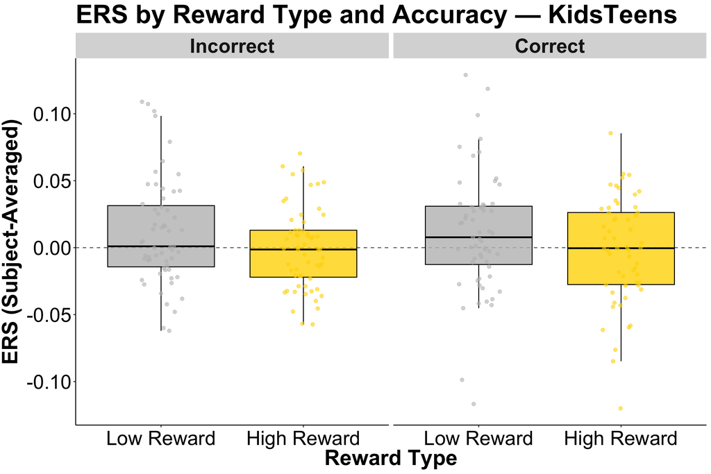

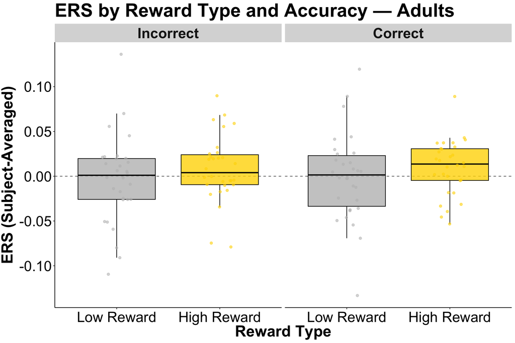

## VTA high > low activation by age

```
##
## Call:
## lm(formula = VTA ~ ageScaled + HighRewardStim, data = anthippRSAdatawbehavfullruns)
##
## Residuals:
##      Min       1Q   Median       3Q      Max
## -0.74648 -0.23501 -0.02059  0.23303  0.98770
##
## Coefficients:
##                                       Estimate Std. Error t value Pr(>|t|)
## (Intercept)                            0.19614    0.05728   3.424  0.00103 **
## ageScaled                              0.08584    0.04163   2.062  0.04295 *
## HighRewardStimHigh Reward Cat - Place -0.09552    0.08276  -1.154  0.25237
## ---
## Signif. codes:  0 '***' 0.001 '**' 0.01 '*' 0.05 '.' 0.1 ' ' 1
##
## Residual standard error: 0.3529 on 70 degrees of freedom
## Multiple R-squared:  0.0715, Adjusted R-squared:  0.04497
## F-statistic: 2.695 on 2 and 70 DF,  p-value: 0.07455
```

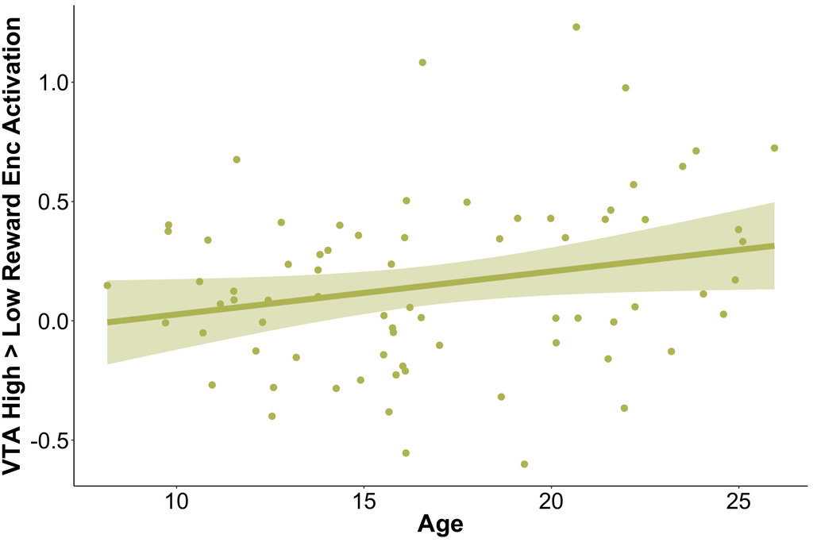